# ASCAT.sc: methylation-data

Maxime Tarabichi maxime.tarabichi@gmail.com

14 February, 2020

## Introduction

In this vignette we use ASCAT.sc together with minfi and conumee to extract copy number profiles from methylation array data.

```r
## ##################################################
library(ASCAT.sc)
library(minfi)
library(conumee)
## ##################################################
```

## ASCAT.sc on undifferentiated sarcomas methylation arrays

We analyse a set of undifferentiated sarcomas (USARC, downloadable [here](https://www.ebi.ac.uk/arrayexpress/experiments/E-MTAB-6961/?query=Nischalan+Pillay)) for which whole genome and targeted sequencing is also available to compare.

First we have to pre-process the data. For this, we use minfi and the rationale behind conumee.

The step we are adding at the end of the typical conumee cnv analysis is the fitting step, where we try and guess the purity of the sample (i.e. the fraction of tumour cells) through fitting integer copy numbers to the track. The idea is that a change in intensity due to clonal copy number changes (i.e. copy number changes present in all the tumour cells) will be proportional to the purity of the sample.

### Load and preprocess data

First we load the raw data (here a set of undifferentiated sarcomas) and extract the technical signal from the normal panel (skeletal muscle) in the data. If you do not have a panel of normal, you can use normal diploid samples from another dataset on the same platform (e.g. downloadable from [ArrayExpress](https://www.ebi.ac.uk/arrayexpress/)). We also load [pre-computed bins](https://github.com/mwsill/mnp_training/blob/master/CNV_data/CNanalysis4_conumee_ANNO.vh20150715.RData) for this platform. These steps might take a bit of time and memory depending on the size of your dataset. Here we load and process 90+ samples in less than 10 minutes and it takes up to 8GB RAM before garbage collection.

```r
## ##################################################
## Chromosomes to fit (here all autosomes)
ALLCHR <- paste0("chr",c(1:22))
## ##################################################
## Set input directory and read in the files
inputdir <- paste0("../data/methyl/E-MTAB-6961.raw")
rgSet <- read.metharray.exp(inputdir); gc();
normals <- strsplit("200598660066_R06C01,200598660078_R02C01,200598660078_R03C01,200598660078_R04C01,200598660078_R05C01,200598660078_R06C01,200598660078_R07C01,200598660078_R08C01,200598660079_R01C01,200598660079_R02C01,200598660079_R03C01,200598660079_R04C01,200598660081_R08C01",split=",")[[1]]
## ##################################################
## Get raw signals for all samples and the panel of normals
data <- preprocessRaw(rgSet); rm("rgSet"); gc();
## ##################################################
## Load precomputed bins from https://github.com/mwsill/mnp_training
load("CNanalysis4_conumee_ANNO.vh20150715.RData")
## ##################################################
## Extract total intensity and get annotations
totalintensity <- getMeth(data)+getUnmeth(data)+1; gc();
annot <- as.data.frame(getAnnotation(data)); rm("data"); gc();
annot <- annot[annot[,"chr"]%in%ALLCHR,]
## ##################################################
## order chromosome, starts and ends of probes
annot <- annot[order(annot[,"chr"],annot[,"pos"],decreasing=F),]
starts <- as.numeric(as.character(annot[,"pos"]))
ends <- as.numeric(as.character(annot[,"pos"]))
chrs <- as.character(annot[,"chr"])
## ##################################################
## Final ordered total intensities for all and normal
totalintensity <- totalintensity[rownames(annot),]
totalintensityNormal <- totalintensity[,colnames(totalintensity)%in%normals]; gc();
## ##################################################
```

### Correct for panel of normal (PoN)

Next we model the track as a linear combination of the normal samples (diploid) in the panel, as per the [conumee methodology](https://github.com/hovestadt/conumee/blob/master/R/process.R). If you do not have a panel of normal, you can use normal diploid samples from another dataset profiled on the same platform (e.g. downloadable from [ArrayExpress](https://www.ebi.ac.uk/arrayexpress/)).

```r
## ##################################################
## log PoN-fitted intensity values of all probes for all samples
logr <- log2(sapply(1:ncol(totalintensity),function(x)
{
    notalreadyinpanel <- !colnames(totalintensityNormal)%in%colnames(totalintensity)[x]
    predicted <- lm(y~.-1,
                    data=data.frame(y=totalintensity[,x],
                                    X=totalintensityNormal[,notalreadyinpanel]))$fitted.values
    predicted[predicted<1] <- 1
    totalintensity[,x]/predicted
}))
colnames(logr) <- colnames(totalintensity); gc();
## ##################################################
```

### Segmenting the logr track

Next we bin the probes and segment the binned tracks. In this vignette, we only process one sample for the sake of clarity in the following steps - but the user should try and process all and look at the results to gain more insight into how well the fitting is working.

```r
## ##################################################
track <- list()
for(samp in colnames(logr)[1])
{
    ## ##################################################
    .logr <- logr[,samp]
    ## ##################################################
    input <- meth_bin(.logr,
                      starts=starts,
                      ends=ends,
                      chrs=chrs,
                      anno@bins)
    track[[samp]] <- getTrackForAll.bins(input[[1]],
                                         input[[4]],
                                         input[[2]],
                                         input[[3]],
                                         allchr=gsub("chr","",ALLCHR))
    ## ##################################################
}
## ##################################################
```

### (Re-)fitting to integers while inferring the purity and ploidy

Finally, we fit the segmented track to integers, inferring the purity of the sample. We plot the best solution among the possible combinations of average ploidy and purity that are considered.

#### Gamma parameter

In the original ASCAT publication, the logr equation for array-based copy number includes a platform-specific “gamma” parameter:

$$logr=\gamma log_2(\frac{2(1-\rho )+\rho n_{tot}}{\psi })$$

Unlike for sequencing, hybridisation-based logr is not linearly proportional to the DNA content. The gamma parameter gamma=0.55 was test for Illumina Array on this series, for which we also have whole-genome sequencing for a subset of 51 samples. Later, in this section we show the results of this calibration across the whole cohort.

So, we first set a global variable GAMMA=0.55, which we be passed as arguments to the different functions of the copy number calling pipeline.

```r
## ##################################################
GAMMA <- .55
## ##################################################
```

We know analyse the results on the first sample. We show the solution on the sunrise plot for the first sample, using this gamma parameter, and the corresponding copy number solution.

```r
## ##################################################
solution <- searchGrid(track[[samp]],
                      purs=seq(0.01, 1, 0.01),
                      ploidies=seq(1.5, 6, 0.01),
                      maxTumourPhi=8,
                      gamma=GAMMA)
```

```
#> Solution found.
```

```r
str(solution)
```

```
#> List of 4
#>  $ errs     : num [1:100, 1:451] 0.00673 0.0046 0.00591 0.00604 0.00671 ...
#>   ..- attr(*, "dimnames")=List of 2
#>   .. ..$ : chr [1:100] "0.01" "0.02" "0.03" "0.04" ...
#>   .. ..$ : chr [1:451] "1.5" "1.51" "1.52" "1.53" ...
#>  $ purity   : num 0.79
#>  $ ploidy   : num 4.58
#>  $ ambiguous: logi FALSE
```

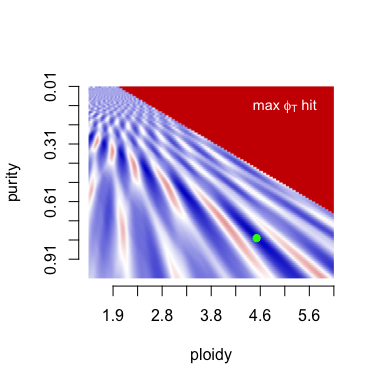

```r
plotSunrise(solution)
## ##################################################
```

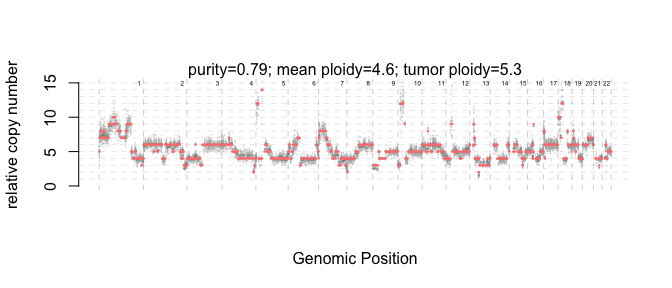

```r
## ##################################################
plotSolution(track[[samp]],
             purity=solution$purity,
             ploidy=solution$ploidy,lwdSeg=2,ylim=c(0,15),
             gamma=GAMMA)
## ##################################################
```

Finally we can get the corresponding copy number profile as a data frame with relevant information for downstream analyses.

```r
profile <- getProfile(fitProfile(track[[samp]],
                                 purity=solution$purity,
                                 ploidy=solution$ploidy,
                                 gamma=GAMMA))
head(profile)
```

```
#>      chromosome    start      end total_copy_number total_copy_number_logr
#> [1,]          1   521369  1350001                 5               5.247375
#> [2,]          1  1400001  6700001                 7               7.117219
#> [3,]          1  6800001 10500001                 8               8.103782
#> [4,]          1 10550001 23300001                 7               7.361633
#> [5,]          1 23450001 29200001                 8               7.626928
#> [6,]          1 29250001 54200001                 7               7.267011
#>              logr    logr.sd
#> [1,] -0.002528904 0.12527837
#> [2,]  0.219902449 0.05240861
#> [3,]  0.316164506 0.04103616
#> [4,]  0.244860860 0.05864849
#> [5,]  0.271091660 0.06202058
#> [6,]  0.235291436 0.05771508
```

```r
knitr::kable(profile, format="html") %>%
    kable_styling() %>%
    scroll_box(width = "100%", height = "200px")
```

| chromosome | start | end | total_copy_number | total_copy_number_logr | logr | logr.sd |
| --- | --- | --- | --- | --- | --- | --- |
| 1 | 521369 | 1350001 | 5 | 5.247375 | -0.0025289 | 0.1252784 |
| 1 | 1400001 | 6700001 | 7 | 7.117219 | 0.2199024 | 0.0524086 |
| 1 | 6800001 | 10500001 | 8 | 8.103782 | 0.3161645 | 0.0410362 |
| 1 | 10550001 | 23300001 | 7 | 7.361633 | 0.2448609 | 0.0586485 |
| 1 | 23450001 | 29200001 | 8 | 7.626928 | 0.2710917 | 0.0620206 |
| 1 | 29250001 | 54200001 | 7 | 7.267011 | 0.2352914 | 0.0577151 |
| 1 | 54250001 | 77700001 | 9 | 8.691675 | 0.3684248 | 0.0738020 |
| 1 | 77750001 | 89500001 | 10 | 10.007317 | 0.4742309 | 0.0607044 |
| 1 | 89600001 | 101750001 | 9 | 9.116754 | 0.4041766 | 0.0561071 |
| 1 | 102450001 | 120747157 | 8 | 8.079049 | 0.3138886 | 0.0608409 |
| 1 | 121086696 | 148900001 | 7 | 7.197222 | 0.2281587 | 0.0855617 |
| 1 | 149200001 | 155700001 | 8 | 8.011157 | 0.3076075 | 0.0710457 |
| 1 | 155800001 | 179550001 | 9 | 8.929096 | 0.3885916 | 0.0764476 |
| 1 | 179600001 | 186350001 | 5 | 4.931092 | -0.0471895 | 0.0531272 |
| 1 | 186650001 | 198900001 | 4 | 4.180201 | -0.1645218 | 0.0907628 |
| 1 | 200000001 | 207050001 | 5 | 5.123621 | -0.0197055 | 0.0374795 |
| 1 | 207100001 | 223550001 | 4 | 3.820455 | -0.2275412 | 0.0580557 |
| 1 | 223797847 | 236900001 | 4 | 4.088029 | -0.1801974 | 0.0620423 |
| 1 | 236950001 | 239550001 | 3 | 3.033319 | -0.3858444 | 0.0470804 |
| 1 | 240050001 | 247650001 | 4 | 3.849146 | -0.2223272 | 0.0823042 |
| 1 | 247700001 | 249150001 | 4 | 3.519702 | -0.2843617 | 0.1004371 |
| 2 | 10001 | 9100001 | 6 | 5.775224 | 0.0668256 | 0.0503536 |
| 2 | 9150001 | 56400001 | 6 | 6.126595 | 0.1098449 | 0.0503847 |
| 2 | 56450001 | 59500001 | 5 | 5.157429 | -0.0149760 | 0.0534595 |
| 2 | 60650001 | 75900001 | 6 | 6.090287 | 0.1055061 | 0.0589798 |
| 2 | 75950001 | 82750001 | 5 | 5.208184 | -0.0079283 | 0.0411588 |
| 2 | 84100001 | 103400001 | 6 | 6.096019 | 0.1061926 | 0.0604373 |
| 2 | 105000001 | 121300001 | 4 | 3.883767 | -0.2160812 | 0.0652899 |
| 2 | 121350001 | 129450001 | 6 | 6.117133 | 0.1087165 | 0.0464228 |
| 2 | 129650001 | 143900001 | 6 | 5.606190 | 0.0452688 | 0.0593254 |

[output cut: 193 more lines]

#### Refitting copy number

One important step in copy number fitting, is the manual refitting step. Unless given the tumour ploidy experimentally, there is ambiguity in the pairs of ploidy and purity to explain the data. Therefore, it is important to manually review the profile and refit if necessary. There are hints in the data to inform on whether a fit is good or not. Some are present in the data, e.g. we have already coded a hard limit on the fraction of the genome allowed to present homozygous deletion (HD), more is considered impossible as the cells would not be viable. Though we have never seen large portion of the genome with clonal HD across cancer samples, this is a somewhat disputed hypothesis for individual cells. Other hints can be linked to prior knowledge, e.g. papillary thyroid carcinomas are in general close to diploid, so it is unlikely to see a tumour ploidy around 6 in these cancers, whereas undifferentiated sarcomas can show extremely high ploidies and often present with two whole genome doublings.

In this step of the analysis we will refit the profile to a lower ploidy. There are two ways we can do this in ASCAT.sc:

##### First, by performing a restricted grid search on given values of purity and ploidy

Let’s say you believed the tumour ploidy should not be as high. You could run the grid search while setting a maximum tumour ploidy of 4:

```r
## ##################################################
solution <- searchGrid(track[[samp]],
                      purs=seq(0.01, 1, 0.01),
                      ploidies=seq(1.5, 6, 0.01),
                      maxTumourPhi=4,
                      gamma=GAMMA) ## max tumour ploidy is set to 4
```

```
#> Solution found.
```

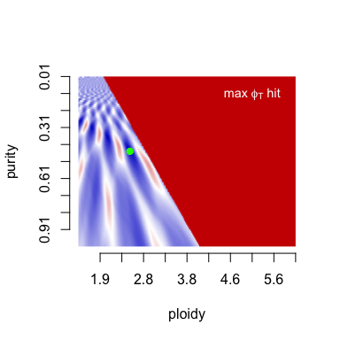

```r
plotSunrise(solution)
## ##################################################
```

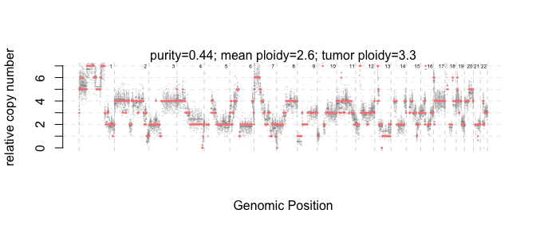

```r
## ##################################################
plotSolution(track[[samp]],
             purity=solution$purity,
             ploidy=solution$ploidy,lwdSeg=2,ylim=c(0,7),
             gamma=GAMMA)
## ##################################################
```

Alternatively you could limit the search for a solution within the boundaries you think are plausible. Say purity by the pathologist is supposed to be much higher (around 90% tumour content) and tumour ploidy is expected to be slightly above 2.

```r
## ##################################################
solution <- searchGrid(track[[samp]],
                      purs=seq(0.7, 1, 0.01), ## purity is at least 70%
                      ploidies=seq(1.5, 3, 0.01),
                      maxTumourPhi=3,
                      gamma=GAMMA)
```

```
#> Solution found.
```

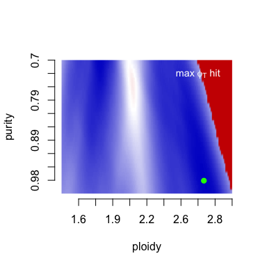

```r
plotSunrise(solution)
## ##################################################
```

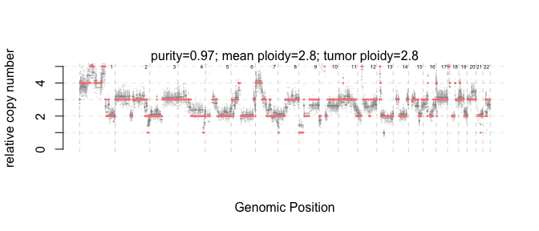

```r
## ##################################################
plotSolution(track[[samp]],
             purity=solution$purity,
             ploidy=solution$ploidy,lwdSeg=2,ylim=c(0,5),
             gamma=GAMMA)
## ##################################################
```

##### Second, fixing the expected integer values of two long segments

Another way to refit a profile is to fix the expected copy number of two big segments on separate chromosomes. The refitting function in ASCAT.sc *refitProfile* will infer the purity and ploidy that could have given rise to these logr values given the integer copy number values that generated them.

```r
## ##################################################
## first solution is the reference solution
firstsolution <- searchGrid(track[[samp]],
                            purs=seq(0.01, 1, 0.01),
                            ploidies=seq(1.5, 6, 0.01),
                            maxTumourPhi=8,
                            gamma=GAMMA)
```

```
#> Solution found.
## refitted solution from the fit using the first solution
## the longest segment on chromosome 17 should align to 5 total copies
## the longest segment on chromosome 6 should align to 3 total copies
```

```r
refittedsolution <- refitProfile(track[[samp]],
                                 firstsolution,
                                 chr1="17",
                                 total1=5,
                                 chr2="6",
                                 total2=3,
                                 gamma=GAMMA)
```

```
#> Solution found.
```

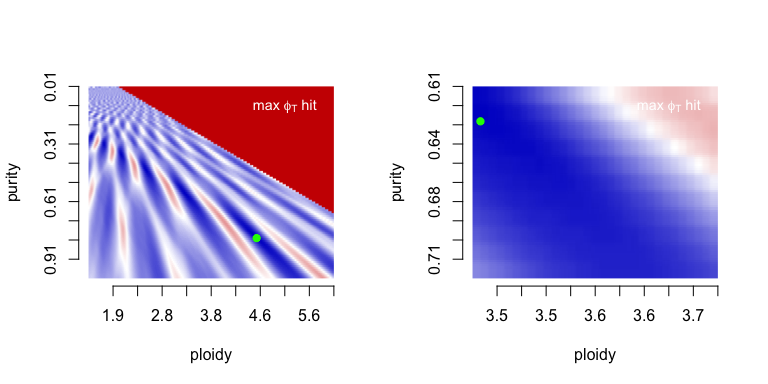

```r
par(mfcol=c(1,2)); plotSunrise(firstsolution); plotSunrise(refittedsolution)
## ##################################################
```

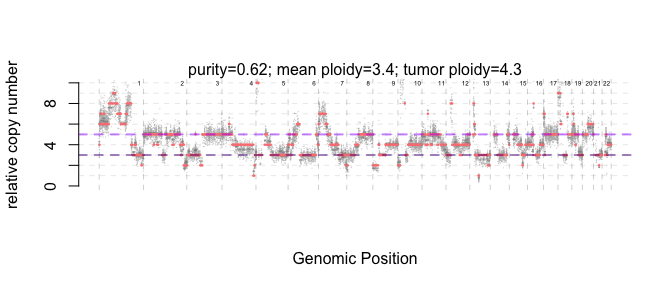

```r
## ##################################################
plotSolution(track[[samp]],
             purity=refittedsolution$purity,
             ploidy=refittedsolution$ploidy,lwdSeg=2,ylim=c(0,10),
             gamma=GAMMA)
abline(h=c(3,5),lwd=2,col=c(rgb(.333,.1019,.545,.5),rgb(.6,.188,1,.5)),lty=2)
## ##################################################
```

The long segments on chromosomes 17 and 6 now align with copy number 5 and 3 respectively (purple segments).

#### Comparing to whole-genome sequencing copy number profiles

Now we will derive the logr track for all methylation samples, which can be run in parallel.

```r
## ##################################################
library(parallel)
## ##################################################
track <- mclapply(colnames(logr),function(samp)
##for(samp in colnames(logr))
{
    cat(".")
    ## ##################################################
    .logr <- logr[,samp]
    ## ##################################################
    input <- meth_bin(.logr,
                      starts=starts,
                      ends=ends,
                      chrs=chrs,
                      anno@bins)
    ##track[[samp]] <-
    getTrackForAll.bins(input[[1]],
                        input[[4]],
                        input[[2]],
                        input[[3]],
                        allchr=gsub("chr","",ALLCHR))
    ## ##################################################
##}
},mc.cores=8)
names(track) <- colnames(logr)
```

And the automated solutions for all samples, also in parallel.

```r
## ##################################################
allSols <- parallel::mclapply(1:length(track),function(x)
{
    cat(".")
    searchGrid(track[[x]],
               purs = seq(0.1, .9, 0.01),
               ploidies = seq(1.7,6.5, 0.01),
               maxTumourPhi=8,gamma=GAMMA)
},mc.cores=8)
## ##################################################

## ##################################################
## extract all aumotated purity and ploidy values
allploidies <- sapply(allSols,function(x) getTumourPhi(x$ploidy,x$purity))
allpurities <- sapply(allSols,function(x) x$purity)
## ##################################################
```

Let’s compare the purity and ploidy values from the automated fits to the whole genome sequencing (WGS) values obtained with Battenberg. We note that the WGS ploidy were manually refitted to match experimental ploidy values obtained independently by FACS and image cytometry.

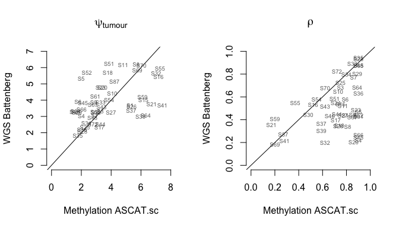

This does not look great! Especially, many samples have ploidy values that are “shifted” by integer values. This is an excellent illustration of the ambuiguity in *in silico* ploidy estimates.

Next, we automate a refitting strategy of the methylation to match the WGS values. We select two large overlapping segments of different total number of copies in the WGS to refit the methylation ploidy values and plot the results after refitting. Coloured samples is where this strategy was applicable. (Manual refitting would likely solve all remaining cases, possible reasons for bad refit: bad sample matching, different copy numbers in methyl and WGS for the selected segments, etc.).

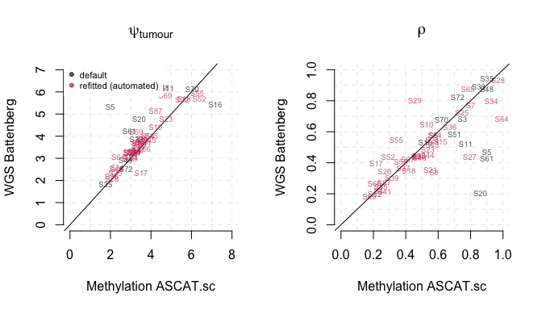

This looks much better, the ploidies align nicely for the refitted profile. As a reminder, we have just forced two large segments to match in terms of total copy number, the rest of the fit, especially the purity is not defined by us, and seem to agree nicely.

Although the average ploidy values seem to match very well, we can ask whether the rest of the copy number segments also match. We derive similarity metrics between all WGS and methyl profiles and plot them in a reducted 2D space using UMAP, where we link pairs of WGS-methyl samples. We use the manhattan distance.

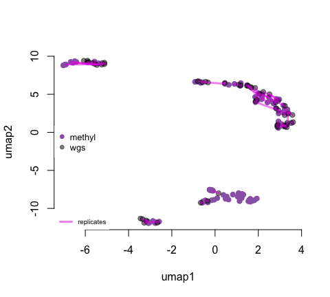

Not reading too much into the clusters, this simply shows that the profiles of replicates give similar total copy number profiles along the whole genome.

## References

Data were collected in the context of a previous project by the Pillay and Flanagan labs at UCL, please cite:  
Steele et al., 2019, Cancer Cell 35, 441–456